# Optimal Treatment Analysis

## Outcome Variable

**Outcome Variable:** ever_wasted

## Predictor Variables

**Intervention Variable:** brthmon

**Adjustment Set:**

unadjusted

## Stratifying Variables

The analysis was stratified on these variable(s):

- agecat
- studyid
- country

## Data Summary

| agecat | studyid | country | brthmon | ever_wasted | n_cell | n |
| --- | --- | --- | --- | --- | --- | --- |
| 0-24 months | ki0047075b-MAL-ED | BANGLADESH | 1 | 0 | 14 | 263 |
| 0-24 months | ki0047075b-MAL-ED | BANGLADESH | 1 | 1 | 7 | 263 |
| 0-24 months | ki0047075b-MAL-ED | BANGLADESH | 2 | 0 | 16 | 263 |
| 0-24 months | ki0047075b-MAL-ED | BANGLADESH | 2 | 1 | 9 | 263 |
| 0-24 months | ki0047075b-MAL-ED | BANGLADESH | 3 | 0 | 9 | 263 |
| 0-24 months | ki0047075b-MAL-ED | BANGLADESH | 3 | 1 | 15 | 263 |
| 0-24 months | ki0047075b-MAL-ED | BANGLADESH | 4 | 0 | 15 | 263 |
| 0-24 months | ki0047075b-MAL-ED | BANGLADESH | 4 | 1 | 7 | 263 |
| 0-24 months | ki0047075b-MAL-ED | BANGLADESH | 5 | 0 | 15 | 263 |
| 0-24 months | ki0047075b-MAL-ED | BANGLADESH | 5 | 1 | 7 | 263 |
| 0-24 months | ki0047075b-MAL-ED | BANGLADESH | 6 | 0 | 9 | 263 |
| 0-24 months | ki0047075b-MAL-ED | BANGLADESH | 6 | 1 | 2 | 263 |
| 0-24 months | ki0047075b-MAL-ED | BANGLADESH | 7 | 0 | 12 | 263 |
| 0-24 months | ki0047075b-MAL-ED | BANGLADESH | 7 | 1 | 8 | 263 |
| 0-24 months | ki0047075b-MAL-ED | BANGLADESH | 8 | 0 | 22 | 263 |
| 0-24 months | ki0047075b-MAL-ED | BANGLADESH | 8 | 1 | 4 | 263 |
| 0-24 months | ki0047075b-MAL-ED | BANGLADESH | 9 | 0 | 10 | 263 |
| 0-24 months | ki0047075b-MAL-ED | BANGLADESH | 9 | 1 | 13 | 263 |
| 0-24 months | ki0047075b-MAL-ED | BANGLADESH | 10 | 0 | 18 | 263 |
| 0-24 months | ki0047075b-MAL-ED | BANGLADESH | 10 | 1 | 6 | 263 |
| 0-24 months | ki0047075b-MAL-ED | BANGLADESH | 11 | 0 | 14 | 263 |
| 0-24 months | ki0047075b-MAL-ED | BANGLADESH | 11 | 1 | 3 | 263 |
| 0-24 months | ki0047075b-MAL-ED | BANGLADESH | 12 | 0 | 22 | 263 |
| 0-24 months | ki0047075b-MAL-ED | BANGLADESH | 12 | 1 | 6 | 263 |
| 0-24 months | ki0047075b-MAL-ED | BRAZIL | 1 | 0 | 13 | 233 |
| 0-24 months | ki0047075b-MAL-ED | BRAZIL | 1 | 1 | 2 | 233 |
| 0-24 months | ki0047075b-MAL-ED | BRAZIL | 2 | 0 | 22 | 233 |
| 0-24 months | ki0047075b-MAL-ED | BRAZIL | 2 | 1 | 3 | 233 |
| 0-24 months | ki0047075b-MAL-ED | BRAZIL | 3 | 0 | 19 | 233 |
| 0-24 months | ki0047075b-MAL-ED | BRAZIL | 3 | 1 | 1 | 233 |

[output cut: 2034 more lines]

The following strata were considered:

- agecat: 0-24 months, studyid: ki0047075b-MAL-ED, country: BANGLADESH
- agecat: 0-24 months, studyid: ki0047075b-MAL-ED, country: BRAZIL
- agecat: 0-24 months, studyid: ki0047075b-MAL-ED, country: INDIA
- agecat: 0-24 months, studyid: ki0047075b-MAL-ED, country: NEPAL
- agecat: 0-24 months, studyid: ki0047075b-MAL-ED, country: PERU
- agecat: 0-24 months, studyid: ki0047075b-MAL-ED, country: SOUTH AFRICA
- agecat: 0-24 months, studyid: ki0047075b-MAL-ED, country: TANZANIA, UNITED REPUBLIC OF
- agecat: 0-24 months, studyid: ki1000108-CMC-V-BCS-2002, country: INDIA
- agecat: 0-24 months, studyid: ki1000108-IRC, country: INDIA
- agecat: 0-24 months, studyid: ki1000109-EE, country: PAKISTAN
- agecat: 0-24 months, studyid: ki1000109-ResPak, country: PAKISTAN
- agecat: 0-24 months, studyid: ki1000304b-SAS-CompFeed, country: INDIA
- agecat: 0-24 months, studyid: ki1000304b-SAS-FoodSuppl, country: INDIA
- agecat: 0-24 months, studyid: ki1017093-NIH-Birth, country: BANGLADESH
- agecat: 0-24 months, studyid: ki1066203-TanzaniaChild2, country: TANZANIA, UNITED REPUBLIC OF
- agecat: 0-24 months, studyid: ki1101329-Keneba, country: GAMBIA
- agecat: 0-24 months, studyid: ki1112895-Guatemala BSC, country: GUATEMALA
- agecat: 0-24 months, studyid: ki1112895-iLiNS-Zinc, country: BURKINA FASO
- agecat: 0-24 months, studyid: ki1113344-GMS-Nepal, country: NEPAL
- agecat: 0-24 months, studyid: ki1114097-CMIN, country: BANGLADESH
- agecat: 0-24 months, studyid: ki1114097-CMIN, country: BRAZIL
- agecat: 0-24 months, studyid: ki1114097-CMIN, country: GUINEA-BISSAU
- agecat: 0-24 months, studyid: ki1114097-CMIN, country: PERU
- agecat: 0-24 months, studyid: ki1114097-CONTENT, country: PERU
- agecat: 0-24 months, studyid: ki1119695-PROBIT, country: BELARUS
- agecat: 0-24 months, studyid: ki1126311-ZVITAMBO, country: ZIMBABWE
- agecat: 0-24 months, studyid: ki1148112-LCNI-5, country: MALAWI
- agecat: 0-24 months, studyid: kiGH5241-JiVitA-3, country: BANGLADESH
- agecat: 0-24 months, studyid: kiGH5241-JiVitA-4, country: BANGLADESH
- agecat: 0-6 months, studyid: ki0047075b-MAL-ED, country: BANGLADESH
- agecat: 0-6 months, studyid: ki0047075b-MAL-ED, country: BRAZIL
- agecat: 0-6 months, studyid: ki0047075b-MAL-ED, country: INDIA
- agecat: 0-6 months, studyid: ki0047075b-MAL-ED, country: NEPAL
- agecat: 0-6 months, studyid: ki0047075b-MAL-ED, country: PERU
- agecat: 0-6 months, studyid: ki0047075b-MAL-ED, country: SOUTH AFRICA
- agecat: 0-6 months, studyid: ki0047075b-MAL-ED, country: TANZANIA, UNITED REPUBLIC OF
- agecat: 0-6 months, studyid: ki1000108-CMC-V-BCS-2002, country: INDIA
- agecat: 0-6 months, studyid: ki1000108-IRC, country: INDIA
- agecat: 0-6 months, studyid: ki1000109-EE, country: PAKISTAN
- agecat: 0-6 months, studyid: ki1000109-ResPak, country: PAKISTAN
- agecat: 0-6 months, studyid: ki1000304b-SAS-CompFeed, country: INDIA
- agecat: 0-6 months, studyid: ki1000304b-SAS-FoodSuppl, country: INDIA
- agecat: 0-6 months, studyid: ki1017093-NIH-Birth, country: BANGLADESH
- agecat: 0-6 months, studyid: ki1066203-TanzaniaChild2, country: TANZANIA, UNITED REPUBLIC OF
- agecat: 0-6 months, studyid: ki1101329-Keneba, country: GAMBIA
- agecat: 0-6 months, studyid: ki1112895-Guatemala BSC, country: GUATEMALA
- agecat: 0-6 months, studyid: ki1113344-GMS-Nepal, country: NEPAL
- agecat: 0-6 months, studyid: ki1114097-CMIN, country: BANGLADESH
- agecat: 0-6 months, studyid: ki1114097-CMIN, country: BRAZIL
- agecat: 0-6 months, studyid: ki1114097-CMIN, country: GUINEA-BISSAU
- agecat: 0-6 months, studyid: ki1114097-CMIN, country: PERU
- agecat: 0-6 months, studyid: ki1114097-CONTENT, country: PERU
- agecat: 0-6 months, studyid: ki1119695-PROBIT, country: BELARUS
- agecat: 0-6 months, studyid: ki1126311-ZVITAMBO, country: ZIMBABWE
- agecat: 0-6 months, studyid: ki1148112-LCNI-5, country: MALAWI
- agecat: 0-6 months, studyid: kiGH5241-JiVitA-3, country: BANGLADESH
- agecat: 0-6 months, studyid: kiGH5241-JiVitA-4, country: BANGLADESH
- agecat: 6-24 months, studyid: ki0047075b-MAL-ED, country: BANGLADESH
- agecat: 6-24 months, studyid: ki0047075b-MAL-ED, country: BRAZIL
- agecat: 6-24 months, studyid: ki0047075b-MAL-ED, country: INDIA
- agecat: 6-24 months, studyid: ki0047075b-MAL-ED, country: NEPAL
- agecat: 6-24 months, studyid: ki0047075b-MAL-ED, country: PERU
- agecat: 6-24 months, studyid: ki0047075b-MAL-ED, country: SOUTH AFRICA
- agecat: 6-24 months, studyid: ki0047075b-MAL-ED, country: TANZANIA, UNITED REPUBLIC OF
- agecat: 6-24 months, studyid: ki1000108-CMC-V-BCS-2002, country: INDIA
- agecat: 6-24 months, studyid: ki1000108-IRC, country: INDIA
- agecat: 6-24 months, studyid: ki1000109-EE, country: PAKISTAN
- agecat: 6-24 months, studyid: ki1000109-ResPak, country: PAKISTAN
- agecat: 6-24 months, studyid: ki1000304b-SAS-CompFeed, country: INDIA
- agecat: 6-24 months, studyid: ki1000304b-SAS-FoodSuppl, country: INDIA
- agecat: 6-24 months, studyid: ki1017093-NIH-Birth, country: BANGLADESH
- agecat: 6-24 months, studyid: ki1066203-TanzaniaChild2, country: TANZANIA, UNITED REPUBLIC OF
- agecat: 6-24 months, studyid: ki1101329-Keneba, country: GAMBIA
- agecat: 6-24 months, studyid: ki1112895-Guatemala BSC, country: GUATEMALA
- agecat: 6-24 months, studyid: ki1112895-iLiNS-Zinc, country: BURKINA FASO
- agecat: 6-24 months, studyid: ki1113344-GMS-Nepal, country: NEPAL
- agecat: 6-24 months, studyid: ki1114097-CMIN, country: BANGLADESH
- agecat: 6-24 months, studyid: ki1114097-CMIN, country: BRAZIL
- agecat: 6-24 months, studyid: ki1114097-CMIN, country: GUINEA-BISSAU
- agecat: 6-24 months, studyid: ki1114097-CMIN, country: PERU
- agecat: 6-24 months, studyid: ki1114097-CONTENT, country: PERU
- agecat: 6-24 months, studyid: ki1119695-PROBIT, country: BELARUS
- agecat: 6-24 months, studyid: ki1126311-ZVITAMBO, country: ZIMBABWE
- agecat: 6-24 months, studyid: ki1148112-LCNI-5, country: MALAWI
- agecat: 6-24 months, studyid: kiGH5241-JiVitA-3, country: BANGLADESH
- agecat: 6-24 months, studyid: kiGH5241-JiVitA-4, country: BANGLADESH

### Dropped Strata

Some strata were dropped due to rare outcomes:

- agecat: 0-24 months, studyid: ki0047075b-MAL-ED, country: BANGLADESH
- agecat: 0-24 months, studyid: ki0047075b-MAL-ED, country: BRAZIL
- agecat: 0-24 months, studyid: ki0047075b-MAL-ED, country: INDIA
- agecat: 0-24 months, studyid: ki0047075b-MAL-ED, country: NEPAL
- agecat: 0-24 months, studyid: ki0047075b-MAL-ED, country: PERU
- agecat: 0-24 months, studyid: ki0047075b-MAL-ED, country: SOUTH AFRICA
- agecat: 0-24 months, studyid: ki0047075b-MAL-ED, country: TANZANIA, UNITED REPUBLIC OF
- agecat: 0-24 months, studyid: ki1000108-CMC-V-BCS-2002, country: INDIA
- agecat: 0-24 months, studyid: ki1000109-EE, country: PAKISTAN
- agecat: 0-24 months, studyid: ki1000109-ResPak, country: PAKISTAN
- agecat: 0-24 months, studyid: ki1000304b-SAS-CompFeed, country: INDIA
- agecat: 0-24 months, studyid: ki1000304b-SAS-FoodSuppl, country: INDIA
- agecat: 0-24 months, studyid: ki1112895-Guatemala BSC, country: GUATEMALA
- agecat: 0-24 months, studyid: ki1113344-GMS-Nepal, country: NEPAL
- agecat: 0-24 months, studyid: ki1114097-CMIN, country: BRAZIL
- agecat: 0-24 months, studyid: ki1114097-CMIN, country: PERU
- agecat: 0-24 months, studyid: ki1114097-CONTENT, country: PERU
- agecat: 0-24 months, studyid: ki1148112-LCNI-5, country: MALAWI
- agecat: 0-24 months, studyid: kiGH5241-JiVitA-4, country: BANGLADESH
- agecat: 0-6 months, studyid: ki0047075b-MAL-ED, country: BANGLADESH
- agecat: 0-6 months, studyid: ki0047075b-MAL-ED, country: BRAZIL
- agecat: 0-6 months, studyid: ki0047075b-MAL-ED, country: INDIA
- agecat: 0-6 months, studyid: ki0047075b-MAL-ED, country: NEPAL
- agecat: 0-6 months, studyid: ki0047075b-MAL-ED, country: PERU
- agecat: 0-6 months, studyid: ki0047075b-MAL-ED, country: SOUTH AFRICA
- agecat: 0-6 months, studyid: ki0047075b-MAL-ED, country: TANZANIA, UNITED REPUBLIC OF
- agecat: 0-6 months, studyid: ki1000109-EE, country: PAKISTAN
- agecat: 0-6 months, studyid: ki1000109-ResPak, country: PAKISTAN
- agecat: 0-6 months, studyid: ki1000304b-SAS-CompFeed, country: INDIA
- agecat: 0-6 months, studyid: ki1000304b-SAS-FoodSuppl, country: INDIA
- agecat: 0-6 months, studyid: ki1112895-Guatemala BSC, country: GUATEMALA
- agecat: 0-6 months, studyid: ki1113344-GMS-Nepal, country: NEPAL
- agecat: 0-6 months, studyid: ki1114097-CMIN, country: BANGLADESH
- agecat: 0-6 months, studyid: ki1114097-CMIN, country: BRAZIL
- agecat: 0-6 months, studyid: ki1114097-CMIN, country: GUINEA-BISSAU
- agecat: 0-6 months, studyid: ki1114097-CMIN, country: PERU
- agecat: 0-6 months, studyid: ki1114097-CONTENT, country: PERU
- agecat: 0-6 months, studyid: ki1148112-LCNI-5, country: MALAWI
- agecat: 0-6 months, studyid: kiGH5241-JiVitA-4, country: BANGLADESH
- agecat: 6-24 months, studyid: ki0047075b-MAL-ED, country: BANGLADESH
- agecat: 6-24 months, studyid: ki0047075b-MAL-ED, country: BRAZIL
- agecat: 6-24 months, studyid: ki0047075b-MAL-ED, country: INDIA
- agecat: 6-24 months, studyid: ki0047075b-MAL-ED, country: NEPAL
- agecat: 6-24 months, studyid: ki0047075b-MAL-ED, country: PERU
- agecat: 6-24 months, studyid: ki0047075b-MAL-ED, country: SOUTH AFRICA
- agecat: 6-24 months, studyid: ki0047075b-MAL-ED, country: TANZANIA, UNITED REPUBLIC OF
- agecat: 6-24 months, studyid: ki1000108-CMC-V-BCS-2002, country: INDIA
- agecat: 6-24 months, studyid: ki1000109-EE, country: PAKISTAN
- agecat: 6-24 months, studyid: ki1000109-ResPak, country: PAKISTAN
- agecat: 6-24 months, studyid: ki1000304b-SAS-CompFeed, country: INDIA
- agecat: 6-24 months, studyid: ki1000304b-SAS-FoodSuppl, country: INDIA
- agecat: 6-24 months, studyid: ki1112895-Guatemala BSC, country: GUATEMALA
- agecat: 6-24 months, studyid: ki1113344-GMS-Nepal, country: NEPAL
- agecat: 6-24 months, studyid: ki1114097-CMIN, country: BANGLADESH
- agecat: 6-24 months, studyid: ki1114097-CMIN, country: BRAZIL
- agecat: 6-24 months, studyid: ki1114097-CMIN, country: PERU
- agecat: 6-24 months, studyid: ki1114097-CONTENT, country: PERU
- agecat: 6-24 months, studyid: ki1119695-PROBIT, country: BELARUS
- agecat: 6-24 months, studyid: ki1148112-LCNI-5, country: MALAWI
- agecat: 6-24 months, studyid: kiGH5241-JiVitA-4, country: BANGLADESH

## Methods Detail

We’re interested in the causal parameters $E[Y_a]$ for all values of $a \in \mathcal{A}$. These parameters represent the mean outcome if, possibly contrary to fact, we intervened to set all units to have $A=a$. Under the randomization and positivity assumptions, these are identified by the statistical parameters $\psi_a=E_W[E_{Y|A,W}(Y|A=a,W)]$. In addition, we’re interested in the mean of $Y$, $E[Y]$ under no intervention (the observed mean). We will estimate these parameters by using SuperLearner to fit the relevant likelihood factors – $E_{Y|A,W}(Y|A=a,W)$ and $p(A=a|W)$, and then updating our likelihood fit using a joint TMLE.

For unadjusted analyses ($W=\{\}$), initial likelihoods were estimated using Lrnr_glm to estimate the simple $E(Y|A)$ and Lrnr_mean to estimate $p(A)$. For adjusted analyses, a small library containing Lrnr_glmnet, Lrnr_xgboost, and Lrnr_mean was used.

Having estimated these parameters, we will then use the delta method to estimate relative risks and attributable risks relative to a prespecified baseline level of $A$.

# Results Detail

## Results Plots

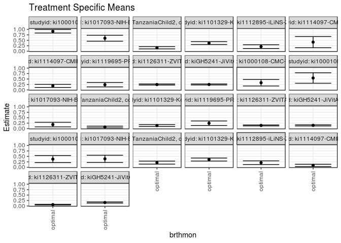

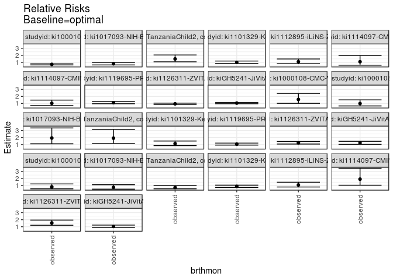

## Results Table

### Parameter: TSM

| agecat | studyid | country | intervention_level | baseline_level | estimate | ci_lower | ci_upper |
| --- | --- | --- | --- | --- | --- | --- | --- |
| 0-24 months | ki1000108-IRC | INDIA | optimal | NA | 0.9137166 | 0.8331959 | 0.9942372 |
| 0-24 months | ki1017093-NIH-Birth | BANGLADESH | optimal | NA | 0.5957214 | 0.4585805 | 0.7328624 |
| 0-24 months | ki1066203-TanzaniaChild2 | TANZANIA, UNITED REPUBLIC OF | optimal | NA | 0.1583486 | 0.1061205 | 0.2105767 |
| 0-24 months | ki1101329-Keneba | GAMBIA | optimal | NA | 0.3720594 | 0.3060841 | 0.4380347 |
| 0-24 months | ki1112895-iLiNS-Zinc | BURKINA FASO | optimal | NA | 0.2105093 | 0.1245956 | 0.2964230 |
| 0-24 months | ki1114097-CMIN | BANGLADESH | optimal | NA | 0.4161381 | 0.1590400 | 0.6732362 |
| 0-24 months | ki1114097-CMIN | GUINEA-BISSAU | optimal | NA | 0.1843653 | 0.1132222 | 0.2555084 |
| 0-24 months | ki1119695-PROBIT | BELARUS | optimal | NA | 0.2380815 | 0.1385931 | 0.3375700 |
| 0-24 months | ki1126311-ZVITAMBO | ZIMBABWE | optimal | NA | 0.2468380 | 0.2214523 | 0.2722238 |
| 0-24 months | kiGH5241-JiVitA-3 | BANGLADESH | optimal | NA | 0.2508636 | 0.2269574 | 0.2747698 |
| 0-6 months | ki1000108-CMC-V-BCS-2002 | INDIA | optimal | NA | 0.3293997 | 0.1801541 | 0.4786454 |
| 0-6 months | ki1000108-IRC | INDIA | optimal | NA | 0.5465616 | 0.3057906 | 0.7873327 |
| 0-6 months | ki1017093-NIH-Birth | BANGLADESH | optimal | NA | 0.1851098 | 0.0796137 | 0.2906060 |
| 0-6 months | ki1066203-TanzaniaChild2 | TANZANIA, UNITED REPUBLIC OF | optimal | NA | 0.0729196 | 0.0354482 | 0.1103910 |
| 0-6 months | ki1101329-Keneba | GAMBIA | optimal | NA | 0.1407152 | 0.0986021 | 0.1828283 |
| 0-6 months | ki1119695-PROBIT | BELARUS | optimal | NA | 0.2458953 | 0.1422774 | 0.3495132 |
| 0-6 months | ki1126311-ZVITAMBO | ZIMBABWE | optimal | NA | 0.1455268 | 0.1235270 | 0.1675266 |
| 0-6 months | kiGH5241-JiVitA-3 | BANGLADESH | optimal | NA | 0.1483294 | 0.1216718 | 0.1749869 |
| 6-24 months | ki1000108-IRC | INDIA | optimal | NA | 0.3752924 | 0.2133643 | 0.5372206 |
| 6-24 months | ki1017093-NIH-Birth | BANGLADESH | optimal | NA | 0.3883438 | 0.2222902 | 0.5543974 |
| 6-24 months | ki1066203-TanzaniaChild2 | TANZANIA, UNITED REPUBLIC OF | optimal | NA | 0.2149809 | 0.1457012 | 0.2842606 |
| 6-24 months | ki1101329-Keneba | GAMBIA | optimal | NA | 0.3555676 | 0.2871511 | 0.4239840 |
| 6-24 months | ki1112895-iLiNS-Zinc | BURKINA FASO | optimal | NA | 0.2105093 | 0.1245956 | 0.2964230 |
| 6-24 months | ki1114097-CMIN | GUINEA-BISSAU | optimal | NA | 0.0867484 | 0.0343099 | 0.1391869 |
| 6-24 months | ki1126311-ZVITAMBO | ZIMBABWE | optimal | NA | 0.0612662 | 0.0463472 | 0.0761853 |
| 6-24 months | kiGH5241-JiVitA-3 | BANGLADESH | optimal | NA | 0.1585703 | 0.1308271 | 0.1863135 |

### Parameter: E(Y)

| agecat | studyid | country | intervention_level | baseline_level | estimate | ci_lower | ci_upper |
| --- | --- | --- | --- | --- | --- | --- | --- |
| 0-24 months | ki1000108-IRC | INDIA | observed | NA | 0.6560976 | 0.6100625 | 0.7021326 |
| 0-24 months | ki1017093-NIH-Birth | BANGLADESH | observed | NA | 0.4775641 | 0.4383415 | 0.5167867 |
| 0-24 months | ki1066203-TanzaniaChild2 | TANZANIA, UNITED REPUBLIC OF | observed | NA | 0.2362270 | 0.2192156 | 0.2532385 |
| 0-24 months | ki1101329-Keneba | GAMBIA | observed | NA | 0.3741007 | 0.3565437 | 0.3916578 |
| 0-24 months | ki1112895-iLiNS-Zinc | BURKINA FASO | observed | NA | 0.2308657 | 0.1897291 | 0.2720024 |
| 0-24 months | ki1114097-CMIN | BANGLADESH | observed | NA | 0.4558824 | 0.3965849 | 0.5151798 |
| 0-24 months | ki1114097-CMIN | GUINEA-BISSAU | observed | NA | 0.1884539 | 0.1687026 | 0.2082051 |
| 0-24 months | ki1119695-PROBIT | BELARUS | observed | NA | 0.2655346 | 0.1719990 | 0.3590703 |
| 0-24 months | ki1126311-ZVITAMBO | ZIMBABWE | observed | NA | 0.2347371 | 0.2277008 | 0.2417734 |
| 0-24 months | kiGH5241-JiVitA-3 | BANGLADESH | observed | NA | 0.2643109 | 0.2552337 | 0.2733881 |
| 0-6 months | ki1000108-CMC-V-BCS-2002 | INDIA | observed | NA | 0.5190217 | 0.4679041 | 0.5701394 |
| 0-6 months | ki1000108-IRC | INDIA | observed | NA | 0.5439024 | 0.4956326 | 0.5921723 |
| 0-6 months | ki1017093-NIH-Birth | BANGLADESH | observed | NA | 0.3569132 | 0.3192325 | 0.3945938 |
| 0-6 months | ki1066203-TanzaniaChild2 | TANZANIA, UNITED REPUBLIC OF | observed | NA | 0.1389816 | 0.1251275 | 0.1528358 |
| 0-6 months | ki1101329-Keneba | GAMBIA | observed | NA | 0.1592121 | 0.1446830 | 0.1737413 |
| 0-6 months | ki1119695-PROBIT | BELARUS | observed | NA | 0.2599065 | 0.1654090 | 0.3544039 |
| 0-6 months | ki1126311-ZVITAMBO | ZIMBABWE | observed | NA | 0.1810500 | 0.1746363 | 0.1874638 |
| 0-6 months | kiGH5241-JiVitA-3 | BANGLADESH | observed | NA | 0.1823042 | 0.1743031 | 0.1903054 |
| 6-24 months | ki1000108-IRC | INDIA | observed | NA | 0.3097561 | 0.2649438 | 0.3545684 |
| 6-24 months | ki1017093-NIH-Birth | BANGLADESH | observed | NA | 0.2939002 | 0.2554778 | 0.3323226 |
| 6-24 months | ki1066203-TanzaniaChild2 | TANZANIA, UNITED REPUBLIC OF | observed | NA | 0.1605550 | 0.1445335 | 0.1765765 |
| 6-24 months | ki1101329-Keneba | GAMBIA | observed | NA | 0.3170197 | 0.2995873 | 0.3344522 |
| 6-24 months | ki1112895-iLiNS-Zinc | BURKINA FASO | observed | NA | 0.2308657 | 0.1897291 | 0.2720024 |
| 6-24 months | ki1114097-CMIN | GUINEA-BISSAU | observed | NA | 0.1666667 | 0.1476863 | 0.1856470 |
| 6-24 months | ki1126311-ZVITAMBO | ZIMBABWE | observed | NA | 0.0939779 | 0.0884472 | 0.0995086 |
| 6-24 months | kiGH5241-JiVitA-3 | BANGLADESH | observed | NA | 0.1651666 | 0.1559963 | 0.1743368 |

### Parameter: RR

| agecat | studyid | country | intervention_level | baseline_level | estimate | ci_lower | ci_upper |
| --- | --- | --- | --- | --- | --- | --- | --- |
| 0-24 months | ki1000108-IRC | INDIA | observed | optimal | 0.7180537 | 0.6478392 | 0.7958782 |
| 0-24 months | ki1017093-NIH-Birth | BANGLADESH | observed | optimal | 0.8016567 | 0.6419088 | 1.0011601 |
| 0-24 months | ki1066203-TanzaniaChild2 | TANZANIA, UNITED REPUBLIC OF | observed | optimal | 1.4918165 | 1.0831127 | 2.0547415 |
| 0-24 months | ki1101329-Keneba | GAMBIA | observed | optimal | 1.0054865 | 0.8473870 | 1.1930832 |
| 0-24 months | ki1112895-iLiNS-Zinc | BURKINA FASO | observed | optimal | 1.0967008 | 0.8096715 | 1.4854823 |
| 0-24 months | ki1114097-CMIN | BANGLADESH | observed | optimal | 1.0955073 | 0.6034743 | 1.9887115 |
| 0-24 months | ki1114097-CMIN | GUINEA-BISSAU | observed | optimal | 1.0221766 | 0.7055548 | 1.4808843 |
| 0-24 months | ki1119695-PROBIT | BELARUS | observed | optimal | 1.1153096 | 0.9650274 | 1.2889951 |
| 0-24 months | ki1126311-ZVITAMBO | ZIMBABWE | observed | optimal | 0.9509761 | 0.8617454 | 1.0494463 |
| 0-24 months | kiGH5241-JiVitA-3 | BANGLADESH | observed | optimal | 1.0536041 | 0.9627518 | 1.1530298 |
| 0-6 months | ki1000108-CMC-V-BCS-2002 | INDIA | observed | optimal | 1.5756594 | 1.0217431 | 2.4298695 |
| 0-6 months | ki1000108-IRC | INDIA | observed | optimal | 0.9951347 | 0.6535089 | 1.5153475 |
| 0-6 months | ki1017093-NIH-Birth | BANGLADESH | observed | optimal | 1.9281158 | 1.1077289 | 3.3560834 |
| 0-6 months | ki1066203-TanzaniaChild2 | TANZANIA, UNITED REPUBLIC OF | observed | optimal | 1.9059564 | 1.1534404 | 3.1494215 |
| 0-6 months | ki1101329-Keneba | GAMBIA | observed | optimal | 1.1314495 | 0.8512147 | 1.5039424 |
| 0-6 months | ki1119695-PROBIT | BELARUS | observed | optimal | 1.0569803 | 0.9225458 | 1.2110049 |
| 0-6 months | ki1126311-ZVITAMBO | ZIMBABWE | observed | optimal | 1.2441009 | 1.0744746 | 1.4405060 |
| 0-6 months | kiGH5241-JiVitA-3 | BANGLADESH | observed | optimal | 1.2290501 | 1.0330488 | 1.4622391 |
| 6-24 months | ki1000108-IRC | INDIA | observed | optimal | 0.8253726 | 0.5477216 | 1.2437705 |
| 6-24 months | ki1017093-NIH-Birth | BANGLADESH | observed | optimal | 0.7568041 | 0.5057659 | 1.1324457 |
| 6-24 months | ki1066203-TanzaniaChild2 | TANZANIA, UNITED REPUBLIC OF | observed | optimal | 0.7468338 | 0.5500634 | 1.0139936 |
| 6-24 months | ki1101329-Keneba | GAMBIA | observed | optimal | 0.8915878 | 0.7414572 | 1.0721170 |
| 6-24 months | ki1112895-iLiNS-Zinc | BURKINA FASO | observed | optimal | 1.0967008 | 0.8096715 | 1.4854823 |
| 6-24 months | ki1114097-CMIN | GUINEA-BISSAU | observed | optimal | 1.9212655 | 1.0638410 | 3.4697488 |
| 6-24 months | ki1126311-ZVITAMBO | ZIMBABWE | observed | optimal | 1.5339276 | 1.2117800 | 1.9417170 |
| 6-24 months | kiGH5241-JiVitA-3 | BANGLADESH | observed | optimal | 1.0415982 | 0.8793729 | 1.2337506 |

### Parameter: PAR

| agecat | studyid | country | intervention_level | baseline_level | estimate | ci_lower | ci_upper |
| --- | --- | --- | --- | --- | --- | --- | --- |
| 0-24 months | ki1000108-IRC | INDIA | optimal | NA | -0.2576190 | -0.3433146 | -0.1719234 |
| 0-24 months | ki1017093-NIH-Birth | BANGLADESH | optimal | NA | -0.1181573 | -0.2500679 | 0.0137532 |
| 0-24 months | ki1066203-TanzaniaChild2 | TANZANIA, UNITED REPUBLIC OF | optimal | NA | 0.0778785 | 0.0270064 | 0.1287505 |
| 0-24 months | ki1101329-Keneba | GAMBIA | optimal | NA | 0.0020413 | -0.0616069 | 0.0656895 |
| 0-24 months | ki1112895-iLiNS-Zinc | BURKINA FASO | optimal | NA | 0.0203564 | -0.0421741 | 0.0828870 |
| 0-24 months | ki1114097-CMIN | BANGLADESH | optimal | NA | 0.0397442 | -0.2081318 | 0.2876203 |
| 0-24 months | ki1114097-CMIN | GUINEA-BISSAU | optimal | NA | 0.0040886 | -0.0642552 | 0.0724324 |
| 0-24 months | ki1119695-PROBIT | BELARUS | optimal | NA | 0.0274531 | -0.0055234 | 0.0604296 |
| 0-24 months | ki1126311-ZVITAMBO | ZIMBABWE | optimal | NA | -0.0121010 | -0.0364226 | 0.0122206 |
| 0-24 months | kiGH5241-JiVitA-3 | BANGLADESH | optimal | NA | 0.0134473 | -0.0091965 | 0.0360911 |
| 0-6 months | ki1000108-CMC-V-BCS-2002 | INDIA | optimal | NA | 0.1896220 | 0.0474578 | 0.3317863 |
| 0-6 months | ki1000108-IRC | INDIA | optimal | NA | -0.0026592 | -0.2325300 | 0.2272116 |
| 0-6 months | ki1017093-NIH-Birth | BANGLADESH | optimal | NA | 0.1718034 | 0.0686125 | 0.2749942 |
| 0-6 months | ki1066203-TanzaniaChild2 | TANZANIA, UNITED REPUBLIC OF | optimal | NA | 0.0660620 | 0.0289743 | 0.1031497 |
| 0-6 months | ki1101329-Keneba | GAMBIA | optimal | NA | 0.0184969 | -0.0215768 | 0.0585706 |
| 0-6 months | ki1119695-PROBIT | BELARUS | optimal | NA | 0.0140112 | -0.0184277 | 0.0464501 |
| 0-6 months | ki1126311-ZVITAMBO | ZIMBABWE | optimal | NA | 0.0355232 | 0.0141682 | 0.0568782 |
| 0-6 months | kiGH5241-JiVitA-3 | BANGLADESH | optimal | NA | 0.0339749 | 0.0081816 | 0.0597681 |
| 6-24 months | ki1000108-IRC | INDIA | optimal | NA | -0.0655363 | -0.2194907 | 0.0884180 |
| 6-24 months | ki1017093-NIH-Birth | BANGLADESH | optimal | NA | -0.0944436 | -0.2518306 | 0.0629434 |
| 6-24 months | ki1066203-TanzaniaChild2 | TANZANIA, UNITED REPUBLIC OF | optimal | NA | -0.0544259 | -0.1204262 | 0.0115744 |
| 6-24 months | ki1101329-Keneba | GAMBIA | optimal | NA | -0.0385478 | -0.1041441 | 0.0270484 |
| 6-24 months | ki1112895-iLiNS-Zinc | BURKINA FASO | optimal | NA | 0.0203564 | -0.0421741 | 0.0828870 |
| 6-24 months | ki1114097-CMIN | GUINEA-BISSAU | optimal | NA | 0.0799183 | 0.0280429 | 0.1317937 |
| 6-24 months | ki1126311-ZVITAMBO | ZIMBABWE | optimal | NA | 0.0327117 | 0.0181590 | 0.0472645 |
| 6-24 months | kiGH5241-JiVitA-3 | BANGLADESH | optimal | NA | 0.0065962 | -0.0202747 | 0.0334672 |

### Parameter: PAF

| agecat | studyid | country | intervention_level | baseline_level | estimate | ci_lower | ci_upper |
| --- | --- | --- | --- | --- | --- | --- | --- |
| 0-24 months | ki1000108-IRC | INDIA | optimal | NA | -0.3926535 | -0.5435929 | -0.2564737 |
| 0-24 months | ki1017093-NIH-Birth | BANGLADESH | optimal | NA | -0.2474167 | -0.5578537 | 0.0011588 |
| 0-24 months | ki1066203-TanzaniaChild2 | TANZANIA, UNITED REPUBLIC OF | optimal | NA | 0.3296763 | 0.0767350 | 0.5133208 |
| 0-24 months | ki1101329-Keneba | GAMBIA | optimal | NA | 0.0054566 | -0.1800984 | 0.1618355 |
| 0-24 months | ki1112895-iLiNS-Zinc | BURKINA FASO | optimal | NA | 0.0881743 | -0.2350688 | 0.3268180 |
| 0-24 months | ki1114097-CMIN | BANGLADESH | optimal | NA | 0.0871809 | -0.6570715 | 0.4971618 |
| 0-24 months | ki1114097-CMIN | GUINEA-BISSAU | optimal | NA | 0.0216955 | -0.4173244 | 0.3247278 |
| 0-24 months | ki1119695-PROBIT | BELARUS | optimal | NA | 0.1033880 | -0.0362400 | 0.2242019 |
| 0-24 months | ki1126311-ZVITAMBO | ZIMBABWE | optimal | NA | -0.0515511 | -0.1604355 | 0.0471166 |
| 0-24 months | kiGH5241-JiVitA-3 | BANGLADESH | optimal | NA | 0.0508769 | -0.0386893 | 0.1327197 |
| 0-6 months | ki1000108-CMC-V-BCS-2002 | INDIA | optimal | NA | 0.3653451 | 0.0212804 | 0.5884553 |
| 0-6 months | ki1000108-IRC | INDIA | optimal | NA | -0.0048891 | -0.5302010 | 0.3400854 |
| 0-6 months | ki1017093-NIH-Birth | BANGLADESH | optimal | NA | 0.4813589 | 0.0972520 | 0.7020336 |
| 0-6 months | ki1066203-TanzaniaChild2 | TANZANIA, UNITED REPUBLIC OF | optimal | NA | 0.4753290 | 0.1330284 | 0.6824814 |
| 0-6 months | ki1101329-Keneba | GAMBIA | optimal | NA | 0.1161779 | -0.1747918 | 0.3350809 |
| 0-6 months | ki1119695-PROBIT | BELARUS | optimal | NA | 0.0539086 | -0.0839570 | 0.1742395 |
| 0-6 months | ki1126311-ZVITAMBO | ZIMBABWE | optimal | NA | 0.1962067 | 0.0693126 | 0.3057995 |
| 0-6 months | kiGH5241-JiVitA-3 | BANGLADESH | optimal | NA | 0.1863635 | 0.0319915 | 0.3161173 |
| 6-24 months | ki1000108-IRC | INDIA | optimal | NA | -0.2115740 | -0.8257451 | 0.1959931 |
| 6-24 months | ki1017093-NIH-Birth | BANGLADESH | optimal | NA | -0.3213459 | -0.9771992 | 0.1169555 |
| 6-24 months | ki1066203-TanzaniaChild2 | TANZANIA, UNITED REPUBLIC OF | optimal | NA | -0.3389860 | -0.8179723 | 0.0138005 |
| 6-24 months | ki1101329-Keneba | GAMBIA | optimal | NA | -0.1215945 | -0.3486955 | 0.0672660 |
| 6-24 months | ki1112895-iLiNS-Zinc | BURKINA FASO | optimal | NA | 0.0881743 | -0.2350688 | 0.3268180 |
| 6-24 months | ki1114097-CMIN | GUINEA-BISSAU | optimal | NA | 0.4795097 | 0.0600099 | 0.7117947 |
| 6-24 months | ki1126311-ZVITAMBO | ZIMBABWE | optimal | NA | 0.3480788 | 0.1747677 | 0.4849919 |
| 6-24 months | kiGH5241-JiVitA-3 | BANGLADESH | optimal | NA | 0.0399369 | -0.1371740 | 0.1894634 |